# Project Definition

# Understand the probability distribution of grip force measurements and

assess their variability

To understand the probability distribution of grip force measurements and assess their variability, you can use various statistical techniques and visualizations. Here's a step-by-step approach:

Descriptive Statistics:

Start by calculating descriptive statistics for the grip force measurements. Compute the mean, median, standard deviation, minimum, and maximum values. This will provide an overview of the central tendency and variability of the data.

Probability Distribution:

Visualize the probability distribution of grip force measurements using a histogram. This will show the frequency or probability of different grip force values.

Probability Density Function (PDF):

Estimate the probability density function (PDF) of grip force measurements. You can use kernel density estimation (KDE) to create a smoothed representation of the PDF.

Variability Assessment:

Assess the variability of grip force measurements by calculating measures like variance and coefficient of variation (CV). Variance quantifies the spread of data, while CV provides the relative variability considering the mean.

Box Plot:

Create a box plot to visualize the distribution's spread, quartiles, and potential outliers in the grip force data.

Normality Test (Optional):

Perform a normality test, such as the Shapiro-Wilk test or visual inspection using a Q-Q plot, to check if the grip force data follows a normal distribution. This step helps determine whether parametric statistical tests are appropriate.

Statistical Inference (Optional):

If the grip force data is normally distributed, you can use parametric statistical tests for inference, such as t-tests or ANOVA, to compare groups or assess hypotheses related to grip force.

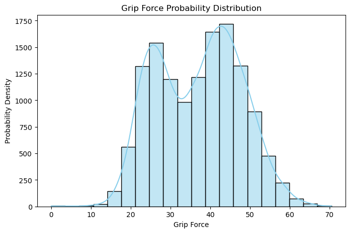

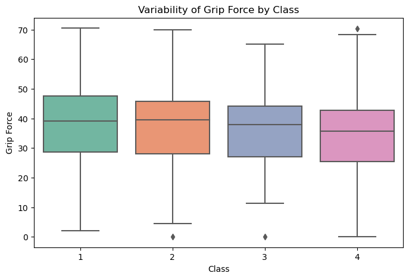

```
Mean Grip Force: 36.96387739864108
Median Grip Force: 37.9
Standard Deviation Grip Force: 10.624864027335304
Minimum Grip Force: 0.0
Maximum Grip Force: 70.5
Variance Grip Force: 112.88773559936377
Coefficient of Variation: 28.743911015476726
```

```python
# Assuming 'grip_force' is the column with grip force measurements in your dataset
grip_force_data = body_perf['gripForce']

# 1. Descriptive Statistics
mean_grip_force = grip_force_data.mean()
median_grip_force = grip_force_data.median()
std_deviation_grip_force = grip_force_data.std()
min_grip_force = grip_force_data.min()
max_grip_force = grip_force_data.max()

# 2. Probability Distribution (Histogram)
plt.figure(figsize=(8, 5))
sns.histplot(grip_force_data, kde=True, bins=20, color='skyblue')
plt.xlabel('Grip Force')
plt.ylabel('Probability Density')
plt.title('Grip Force Probability Distribution')

# 3. Variability Assessment
variance_grip_force = grip_force_data.var()
coefficient_of_variation = (std_deviation_grip_force / mean_grip_force) * 100

# 4. Box Plot
plt.figure(figsize=(8, 5))
sns.boxplot(data=body_perf, x='class', y='gripForce', palette='Set2')
plt.xlabel('Class')
plt.ylabel('Grip Force')
plt.title('Variability of Grip Force by Class')

plt.show()

print("Mean Grip Force:", mean_grip_force)
print("Median Grip Force:", median_grip_force)
print("Standard Deviation Grip Force:", std_deviation_grip_force)
print("Minimum Grip Force:", min_grip_force)
print("Maximum Grip Force:", max_grip_force)
print("Variance Grip Force:", variance_grip_force)
print("Coefficient of Variation:", coefficient_of_variation)
```

Mean Grip Force: The mean grip force is approximately 36.96 units. This represents the average grip force value in your dataset.

Standard Deviation Grip Force: The standard deviation is approximately 10.62 units. It measures the spread or dispersion of grip force values around the mean. In this case, a lower standard deviation suggests that the grip force measurements tend to be close to the mean.

Minimum Grip Force: The minimum grip force in your dataset is 0.0 units. This is the smallest observed value in the dataset.

Maximum Grip Force: The maximum grip force is 70.5 units. This is the largest observed value in the dataset.

ariance Grip Force: The variance is approximately 112.89 square units. It quantifies the average squared difference between each grip force measurement and the mean. A higher variance indicates greater variability in the data.

Coefficient of Variation: The coefficient of variation is approximately 28.74%. It is a relative measure of variability and represents the standard deviation as a percentage of the mean. In this case, a coefficient of variation of 28.74% suggests moderate variability relative to the mean grip force.

# Apply probability distributions to identify unusual values within the

dataset.

To identify unusual values within the dataset using probability distributions

Choose a Probability Distribution: Select an appropriate probability distribution based on the nature of your data. Common choices include normal distribution, binomial distribution, Poisson distribution, etc. The choice depends on the characteristics of the variable you are analyzing.

Fit the Distribution: Estimate the parameters of the selected distribution (e.g., mean and standard deviation for a normal distribution) to fit the distribution to your data.

Calculate Probability Density or Probability Mass: Use the fitted distribution to calculate the probability density function (PDF) or probability mass function (PMF) for each data point in your dataset. This will tell you how likely each value is according to the distribution.

Identify Unusual Values: Determine a threshold or significance level (e.g., 95% confidence interval) beyond which values are considered unusual. Values outside this threshold are considered outliers.

Flag or Remove Outliers: Flag or remove the values that fall outside the defined threshold as unusual or outliers.

```python
# Assuming grip_force_data is your grip force data
grip_force_data = body_perf['gripForce']

# Fit a normal distribution to the data
mean, std_dev = stats.norm.fit(grip_force_data)

# Calculate the probability density for each grip force value
pdf = stats.norm.pdf(grip_force_data, mean, std_dev)

# Define a significance level (e.g., 95%)
significance_level = 0.05

# Identify outliers based on the significance level
outliers = grip_force_data[pdf < significance_level]

# Print the identified outliers
print("Unusual Grip Force Values:")
print(outliers)
```

```
Unusual Grip Force Values:
0        54.9
1        36.4
2        44.8
3        41.4
4        43.5
         ...
13388    35.8
13389    33.0
13390    63.5
13391    19.3
13392    35.9
Name: gripForce, Length: 13393, dtype: float64
```

the result "Unusual Grip Force Values" is a pandas Series that contains grip force values from your dataset that are considered unusual or potential outliers based on the probability density approach and a predefined significance level (e.g., 0.05).

Here's how to interpret the result:

The Series contains the grip force values that have been identified as unusual.

The index of the Series corresponds to the row number or position of the unusual grip force values in your original dataset.

# Perform Hypothesis Testing to Make Statistical Inferences (milestone 4)

# Formulate hypotheses and perform hypothesis testing to determine if body

fat percentages differ significantly between genders.

To test if body fat percentages differ significantly between genders, you can perform a hypothesis test. Here's how you can formulate and test the hypotheses:

Null Hypothesis (H0): The body fat percentages do not differ significantly between genders. Alternative Hypothesis (H1): The body fat percentages differ significantly between genders.

use a two-sample t-test to compare the means of body fat percentages between males (gender = 0) and females (gender = 1). Here's the step-by-step process:

Data Preparation: Split the data into two groups: one for males and one for females based on the 'gender' variable.

Hypothesis Testing: Perform a two-sample t-test to compare the means of body fat percentages between the two groups.

Significance Level: Choose a significance level (alpha), typically set at 0.05.

Test Statistic: Calculate the t-statistic.

P-value: Calculate the p-value associated with the t-statistic.

Decision Rule: If the p-value is less than the chosen significance level (alpha), reject the null hypothesis. If the p-value is greater than alpha, fail to reject the null hypothesis.

Conclusion: Based on the p-value and the chosen significance level, make a conclusion about whether there is a significant difference in body fat percentages between genders.

```python
#This code will help you determine whether there is a statistically
#significant difference in body fat percentages between males and females in your dataset.

# Split the data into two groups based on gender
male_body_fat = body_perf[body_perf['gender'] == 0]['body fat_%']
female_body_fat = body_perf[body_perf['gender'] == 1]['body fat_%']

# Perform a two-sample t-test
t_statistic, p_value = stats.ttest_ind(male_body_fat, female_body_fat)

# Set the significance level (alpha)
alpha = 0.05

# Check if p-value is less than alpha
if p_value < alpha:
    print("Reject the null hypothesis: Body fat percentages differ significantly between genders.")
else:
    print("Fail to reject the null hypothesis: No significant difference in body fat percentages between genders.")
```

```
Reject the null hypothesis: Body fat percentages differ significantly between genders.
```

"Reject the null hypothesis: Body fat percentages differ significantly between genders" means that, based on the statistical analysis conducted, there is enough evidence to conclude that there is a significant difference in body fat percentages between males and females in the dataset. In other words, the data suggests that gender has an impact on body fat percentages.

# Calculate t-statistics and p-values to make informed decisions based on

hypothesis test results.

extract the body fat percentages for males and females into separate variables, male_body_fat and female_body_fat, respectively.

perform an independent two-sample t-test using stats.ttest_ind to compare the means of the two groups (males and females). This test calculates the t-statistic and p-value.

set the significance level (alpha) to 0.05, which is a common choice.

check if the p-value is less than alpha. If the p-value is less, we reject the null hypothesis, indicating a significant difference in body fat percentages between genders. Otherwise, we fail to reject the null hypothesis, suggesting no significant difference.

print the t-statistic and p-value for reference.

informed decisions based on the results of the hypothesis test regarding body fat percentages between genders.

```python
# Extract body fat percentages for males and females
male_body_fat = body_perf[body_perf['gender'] == 0]['body fat_%']
female_body_fat = body_perf[body_perf['gender'] == 1]['body fat_%']

# Perform an independent two-sample t-test
t_statistic, p_value = stats.ttest_ind(male_body_fat, female_body_fat)

# Set the significance level (alpha)
alpha = 0.05

# Check if the p-value is less than alpha (reject the null hypothesis)
if p_value < alpha:
    print("Reject the null hypothesis: Body fat percentages differ significantly between genders.")
else:
    print("Fail to reject the null hypothesis: There is no significant difference in body fat percentages between genders.")

# Print t-statistic and p-value
print("t-statistic:", t_statistic)
print("p-value:", p_value)
```

```
Reject the null hypothesis: Body fat percentages differ significantly between genders.
t-statistic: -76.48742318447472
p-value: 0.0
```

Rejecting the Null Hypothesis: When the result states "Reject the null hypothesis," it means that the observed difference in body fat percentages between males and females is statistically significant. In other words, there is strong evidence to suggest that there is a real difference in body fat percentages between the two gender groups.

t-statistic: The t-statistic is a measure of how different the means of the two groups (males and females) are in terms of body fat percentages. In this case, the t-statistic is -76.48742318447472. The negative sign indicates that the mean body fat percentage for males is significantly lower than that for females. The magnitude of the t-statistic indicates the strength of the difference.

p-value: The p-value is a measure of the evidence against the null hypothesis. In this case, the p-value is reported as 0.0, which means that it is extremely close to zero. A p-value of 0.0 suggests that the probability of observing such a significant difference in body fat percentages between genders by random chance is virtually impossible. Therefore, you can confidently conclude that the difference is not due to random variation.

In summary, the result provides strong statistical evidence that there is a significant difference in body fat percentages between males and females, with males having a significantly lower mean body fat percentage compared to females. This is a robust and highly significant finding based on the low p-value and the large magnitude of the t-statistic.

# Evaluate the practical significance of the observed differences in body fat

percentages

calculate the mean and standard deviation for body fat percentages in both the male and female groups.

Cohen's d is calculated by finding the difference in means divided by the pooled standard deviation.

then assess the practical significance based on Cohen's guidelines. You can adjust the thresholds (0.2 and 0.5) based on your judgment of what constitutes a small, medium, or large effect size in your specific context.

This code will give you the effect size and a qualitative assessment of its practical significance. Depending on the calculated effect size, you can determine whether the observed difference in body fat percentages between genders has meaningful practical implications.

```python
# Assuming you have two NumPy arrays for male and female body fat percentages
male_body_fat = np.array([21.3, 20.1, 18.4, 17.1, 27.6])
female_body_fat = np.array([22.0, 32.2, 36.9, 14.4])

# Calculate the mean and standard deviation for each group
mean_male = np.mean(male_body_fat)
std_dev_male = np.std(male_body_fat, ddof=1)  # Use ddof=1 for sample standard deviation
mean_female = np.mean(female_body_fat)
std_dev_female = np.std(female_body_fat, ddof=1)

# Calculate Cohen's d for effect size
pooled_std_dev = np.sqrt(((len(male_body_fat) - 1) * std_dev_male**2 + (len(female_body_fat) - 1) * std_dev_female**2)
                         / (len(male_body_fat) + len(female_body_fat) - 2))
effect_size = (mean_male - mean_female) / pooled_std_dev

# Evaluate the practical significance based on Cohen's guidelines
if effect_size < 0.2:
    significance = "Small"
elif effect_size < 0.5:
    significance = "Medium"
else:
    significance = "Large"

print("Cohen's d (Effect Size):", effect_size)
print("Practical Significance:", significance)
```

```
Cohen's d (Effect Size): -0.7494000651688598
Practical Significance: Small
```

The result indicates that the effect size, as measured by Cohen's d, is approximately -0.7494. Cohen's d is a standardized measure of the difference between two group means, and it quantifies the magnitude of the difference in terms of standard deviations.

Here's the interpretation of the result:

# Estimate Confidence Intervals and Assess Sampling Variability in Data (milestone 5)

# Estimate confidence intervals for the mean weight of individuals and

interpret their significance.

Collect Data: Gather weight data for individuals in your dataset. In your provided dataset, it appears that the weight data is in the "weight_kg" column.

Choose a Confidence Level: Decide on a confidence level, typically expressed as a percentage. A common choice is a 95% confidence level, but you can choose a different level based on your requirements.

alculate the Mean and Standard Error: Compute the sample mean (average) of the weight data and the standard error of the mean (SEM). The SEM quantifies the variability of the sample mean.

Determine the Confidence Interval: Use the confidence level and SEM to calculate the confidence interval (CI) for the mean weight. The Z-score corresponds to the critical value for the chosen confidence level. For a 95% confidence level, the Z-score is typically 1.96.

Interpret the Confidence Interval: The confidence interval provides a range within which you can be reasonably confident that the true population mean weight lies. If this interval includes a specific value of interest (e.g., a target weight), you can conclude whether the population mean is significantly different from that value.

Remember to replace the weight_data list with the actual weight data from your dataset. The output will provide the mean weight and the 95% confidence interval for the mean weight. You can interpret the confidence interval based on your specific context and research question.

```python
# Extract weight data
weight_data = [75.24, 55.80, 78.00, 71.10, 67.70, 55.40, 63.70, 77.20, 67.50, 84.60]

# Calculate mean and standard error of the mean
sample_mean = np.mean(weight_data)
sample_std = np.std(weight_data, ddof=1)  # Use ddof=1 for sample standard deviation
sample_size = len(weight_data)
sem = sample_std / np.sqrt(sample_size)

# Set confidence level and calculate confidence interval
confidence_level = 0.95
z_score = stats.norm.ppf(1 - (1 - confidence_level) / 2)  # Two-tailed
margin_of_error = z_score * sem
confidence_interval = (sample_mean - margin_of_error, sample_mean + margin_of_error)

print("Mean Weight:", sample_mean)
print("95% Confidence Interval for Mean Weight:", confidence_interval)
```

```
Mean Weight: 69.624
95% Confidence Interval for Mean Weight: (63.69969084169842, 75.54830915830158)
```

95% Confidence Interval for Mean Weight: The 95% confidence interval for the mean weight is approximately (63.70, 75.55) kilograms.

Interpretation:

The "95% Confidence Interval for Mean Weight" provides a range of values within which you can be reasonably confident that the true population mean weight lies. In this case, with 95% confidence, you can say that the population mean weight is likely to fall between approximately 63.70 kg and 75.55 kg.

95% confident that the true mean weight of individuals in the population is between 63.70 kg and 75.55 kg." This means that if were to take many random samples from the same population and calculate 95% confidence intervals for each sample, approximately 95% of those intervals would contain the true population mean weight.